# 1-Session One Introduction to Python Jupyter Notebook and Basic Data Types

[figure not shown]

### A Brief History of Python

Python was created by Guido van Rossum in the late 1980s and was first released in 1991. It was designed as a high-level, interpreted language with a focus on code readability and simplicity. The language takes inspiration from ABC, C, and Modula-3, aiming to provide a more approachable and efficient programming experience. Over the years, Python has evolved into one of the most widely used programming languages in data science, web development, automation, and artificial intelligence. Its vast ecosystem of libraries and strong community support make it a preferred choice for statistical analysis and machine learning.

### Overview of Python and Jupyter Notebook

Python is a versatile and widely used programming language in data analysis, machine learning, and statistical computing. It is popular due to its simplicity, readability, and vast ecosystem of libraries that support numerical computing, data manipulation, and visualization.

Jupyter Notebook is an interactive web-based environment that allows users to write and execute Python code in a document-like format. It supports text, code execution, visualizations, and markdown documentation within a single file.

### Installing Python and Jupyter Notebook

#### Python can be installed via:

Anaconda Distribution (Recommended): Comes with Python, Jupyter Notebook, and essential libraries pre-installed.

Standalone Python Installation: Using official Python downloads from python.org, followed by manual installation of Jupyter Notebook.

#### Steps to Install Using Anaconda:

Download and install Anaconda.

Open Anaconda Navigator and launch Jupyter Notebook.

#### Steps to Install Using pip:

Install Python from python.org.

Open the terminal or command prompt and run:

## Method 1: Install PIP on Windows Using get-pip.py

The first method uses cURL to download the installation file and additional configuration steps post-installation. Follow the steps below to install PIP using this methodpt:

### Step 1: Download PIP get-pip.py

Before installing PIP, download the get-pip.py file. Run the following cURL command in the command prompt:

```python
#curl https://bootstrap.pypa.io/get-pip.py -o get-pip.py
```

### Step 2: Installing PIP on Windows

To install PIP, run the following Python command:

```python
#python get-pip.py
```

### Step 3: Verify Installation

To test whether the installation was successful, type the following command:

```python
#python -m pip help
```

## Check PIP version installed

```python
#pip --version
```

## Now install Jupyter Notebook and Jupyterlab

```python
#pip install jupyter
```

```python
#pip install notebook
```

```python
#pip install jupyterlab
```

### Check the available jupyter version

```python
#jupyter --version
```

## Jupyter Notebook Interface

Key components of Jupyter Notebook:

- Cells: Code and text (Markdown) can be written in separate cells.
- Kernel: The processing engine that executes code.
- Output: The results of executed code appear below the respective cell.

Basic Jupyter Notebook Commands

- Run a cell: Shift + Enter
- Insert a new cell: Esc + B
- Delete a cell: Esc + D + D
- Change cell type (Code/Markdown): Esc + M (for Markdown) or Esc + Y (for Code)

## Basic Python Syntax and Data Types

### Vectors

Vectors are one-dimensional data structures that store elements of the same type. They are commonly used in numerical computing and can represent mathematical quantities such as coordinates or time series data. In Python, vectors are typically implemented using lists or specialized numerical libraries such as NumPy.

### Lists

Lists are ordered, mutable collections that can store elements of different types. They allow for dynamic resizing and provide various methods for element addition, removal, and manipulation. Lists are widely used in data storage, iteration, and flexible data handling.

### Matrices

Matrices are two-dimensional structures that store data in rows and columns. They are essential in linear algebra, data transformations, and machine learning applications. Matrices facilitate mathematical operations such as addition, multiplication, and inversion. In Python, they are commonly handled using NumPy for efficient computation.

### Tuples

Tuples are ordered collections similar to lists but are immutable, meaning their elements cannot be modified after creation. They are useful for storing fixed data, ensuring data integrity, and enhancing performance when iteration or access speed is critical.

### Dictionaries

Dictionaries are data structures that store key-value pairs, allowing for fast data retrieval. They provide a flexible way to organize and access data based on unique keys. Dictionaries are widely used in applications requiring fast lookups, such as databases and data indexing.

### Arrays

Arrays are homogeneous data structures that store elements of the same type in a contiguous memory location. They offer efficient storage and computation, making them suitable for numerical operations. Unlike lists, arrays require explicit type specification and are often used in scientific computing and large-scale data processing.

# This is my first interaction with python (Basic Python Syntax and Codes)

## Printing Output

```python
print("Hello, world")
```

```
Hello, world
```

```python
print(5+10)
```

```
15
```

# Python Data types with syntax Examples

## 1. Integer: Represent whole numbers

```python
x = 20        # Integer
x
```

```
20
```

## 2. Float: Represents decimal numbers

```python
y = 3.14      # Float
y
```

```
3.14
```

## 3. String: Represents a sequence of characters

```python
name = "Mercy" # String
name

greeting = 'Hello'
greeting
```

```
'Hello'
```

## 4. Boolean: Represents True or False values

```python
is_valid = True # Boolean
is_valid

is_active = False
is_active
```

```
False
```

# 5. List: An ordered, mutable collection of items

```python
fruits = ["apple", "banana", "orange"]
fruits
print(fruits[2])  # Access 3rd element
```

```
orange
```

```python
fruits = ["apple", "banana", "orange"]
print(fruits[0])  # Access first element
print(fruits[1])  # Access second element
print(fruits[2])  # Access third element
```

```
apple
banana
orange
```

# 6. Tuple: An ordered, immutable collection of items

```python
my_tuple = (1,2,3,"John", True)
my_tuple

coordinates = (10, 20)
print(coordinates[1])  # Access second element
```

```
20
```

# 7. Set: An unordered mutable collection of unique items

```python
my_set = {1,2,3,"John"}
my_set
```

```
{1, 2, 3, 'John'}
```

# 8. Dictionary: A collection of key-value pairs

```python
my_dict = {
    "name" : "John",
    "Age": 60,
    "gender": "Male",
    "Occupation": "Doctor"}
my_dict
```

```
{'name': 'John', 'Age': 60, 'gender': 'Male', 'Occupation': 'Doctor'}
```

```python
person = {"name": "John", "age": 25, "ocupation": "Teacher"}
person
```

```
{'name': 'John', 'age': 25, 'ocupation': 'Teacher'}
```

```python
print(person["name"])  # Access value by key
```

```
John
```

# 9. None Type: Represents the absence of a value

```python
x = None
```

# 10. What are Conditional Statements?

### Conditional statements execute different code blocks based on whether a condition is True or False.

### 1. if Statement (do something if true)

```python
age = 18

if age >= 18:
    print("You are an adult")
```

```
You are an adult
```

### 2. if-else Statement (do one thing or another)

```python
age = 15

if age >= 18:
    print("You are an adult")
else:
    print("You are a minor")
```

```
You are a minor
```

### 3. if-elif-else Statement (multiple conditions)

```python
age = 18
if age >= 18:
    print("Adult")
else:
    print("Minor")
```

```
Adult
```

```python
age = 12
if age >= 18:
    print("Adult")
else:
    print("Minor")
```

```
Minor
```

```python
score = 85

if score >= 90:
    print("Grade: A")
elif score >= 80:
    print("Grade: B")
elif score >= 70:
    print("Grade: C")
else:
    print("Grade: F")
```

```
Grade: B
```

# 11. What are Loops?

### Loops execute the same block of code repeatedly until a condition is met. There are two main types: for and while.

### 1. for Loop (repeat a fixed number of times)

#### Basic for loop

```python
# For loop
for i in range(5):
    print(i)
```

```
0
1
2
3
4
```

The code above defines a for loop that iterates over a sequence generated by the range(5) function. The range(5) function produces a sequence of numbers starting from 0 up to, but not including, 5, meaning it generates [0, 1, 2, 3, 4]. During each iteration, the variable i takes on the next value in this sequence, and the print(i) statement outputs the current value of i to the console. As a result, the numbers 0, 1, 2, 3, and 4 are printed sequentially. This type of loop is useful when iterating over a known range of values, such as indexing elements in a list or executing a block of code a fixed number of times.

### Loop through a list

```python
fruits = ['apple', 'banana', 'cherry']

for fruit in fruits:
    print(fruit)
```

```
apple
banana
cherry
```

### Loop through a string

```python
word = "Python"

for letter in word:
    print(letter)
```

```
P
y
t
h
o
n
```

### while Loop (repeat while a condition is True)

```python
# While loop (repeat while a condition is True)
count = 0
while count < 3:
    print(count)
    count += 1
```

```
0
1
2
```

The code defines a while loop that continues executing as long as the condition count < 3 is true. Initially, the variable count is set to 0. During each iteration, the current value of count is printed, and then count is incremented by 1 using count += 1. The loop runs until count reaches 3, at which point the condition count < 3 becomes false, and the loop terminates. As a result, the numbers 0, 1, and 2 are printed sequentially. This type of loop is useful when the number of iterations is not predetermined but depends on a condition being met.

### Range() Function (create a sequence of numbers)

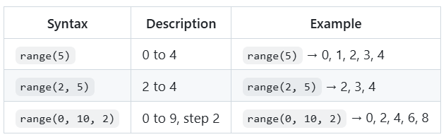

```python
# Count from 1 to 5
for i in range(1, 6):
    print(i)
```

```
1
2
3
4
5
```

### Loop Control Statements

```python
for i in range(10):
    if i == 5:
        break
    print(i)
```

```
0
1
2
3
4
```

### Continue - Skip current iteration

```python
for i in range(5):
    if i == 2:
        continue
    print(i)
```

```
0
1
3
4
```

### Pass - Do nothing (placeholder)

```python
for i in range(3):
    if i == 1:
        pass  # Placeholder for future code
    print(i)
```

```
0
1
2
```

### Nested Loops (loop inside a loop)

```python
for i in range(3):
    for j in range(2):
        print(f"i={i}, j={j}")
```

```
i=0, j=0
i=0, j=1
i=1, j=0
i=1, j=1
i=2, j=0
i=2, j=1
```

### Print a multiplication table

```python
for i in range(1, 4):
    for j in range(1, 4):
        print(f"{i} × {j} = {i*j}")
```

```
1 × 1 = 1
1 × 2 = 2
1 × 3 = 3
2 × 1 = 2
2 × 2 = 4
2 × 3 = 6
3 × 1 = 3
3 × 2 = 6
3 × 3 = 9
```

### Enumerate() - Get index and value

```python
fruits = ['apple', 'banana', 'cherry']

for index, fruit in enumerate(fruits):
    print(f"{index}: {fruit}")
```

```
0: apple
1: banana
2: cherry
```

### zip() - Loop through multiple lists

```python
names = ['Alice', 'Bob', 'Charlie']
scores = [85, 92, 78]

for name, score in zip(names, scores):
    print(f"{name}: {score}")
```

```
Alice: 85
Bob: 92
Charlie: 78
```

### With conditions

```python
even_numbers = [i for i in range(10) if i % 2 == 0]
print(even_numbers)
```

```
[0, 2, 4, 6, 8]
```

### Data Science Example - Loop through DataFrame

```python
import pandas as pd

# Create sample data
data = {
    'name': ['Alice', 'Bob', 'Charlie'],
    'score': [85, 62, 90]
}

df = pd.DataFrame(data)

# Loop through rows
for index, row in df.iterrows():
    print(f"{row['name']} scored {row['score']}")
```

```
Alice scored 85
Bob scored 62
Charlie scored 90
```

# 12. Functions

```python
def greet(name):
    return "Hello, " + name

print(greet("Alice"))
```

```
Hello, Alice
```